# Information Extraction with Snorkel

Matheus Schmitz  
[LinkedIn](https://www.linkedin.com/in/matheusschmitz/)  
[Github Portfolio](https://matheus-schmitz.github.io/)

State-of-the-art extraction techniques require massive labeled training set but it is costly to obtain. To overcome this problem, Snorkel helps rapidly create training sets using the new data programming paradigm. To start, developers focus on writing a set of labeling functions, which are just scripts that programmatically label data. The resulting labels are noisy, but Snorkel uses a generative model to learn how to use those labeling functions to label more data. The new labeled data now can be used to train high-quality end models.

## Prepara Data

```python
# Merge all actor briographies crawled from IMDB
import pandas as pd
import os
if not os.path.isfile('Matheus_Schmitz_hw05_all.tsv'):
    # Read the example dataset
    df1 = pd.read_csv('cast_bios.tsv', sep='\t', header=None)
    print(f'df1.shape: {df1.shape}')

    # Read my dataset from hw02
    df2 = pd.read_csv('Matheus_Schmitz_hw02_bios.csv', header=None)
    df2.to_csv('Matheus_Schmitz_hw05_bio.tsv', header=False, index=False, sep='\t')
    print(f'df2.shape: {df2.shape}')

    # Merge the datasets
    df_merged = pd.concat([df1, df2])
    print(f'df_merged.shape: {df_merged.shape}')

    # Deduplicate
    df_merged.drop_duplicates(inplace=True)
    print(f'deduplication: {df_merged.shape}')

    # Save as CSV and TSV
    df_merged.to_csv('Matheus_Schmitz_hw05_all.csv', header=False, index=False)
    df_merged.to_csv('Matheus_Schmitz_hw05_all.tsv', header=False, index=False, sep='\t')
```

## Prepare Snorkel Environment

Lets install the packages we will use. Through my testing, Snorkel v0.7 works the best with Python 3.6

```python
# Create a new Python 3.6 environment.

!conda create -n py36 python=3.6
```

```python
!pip install -r requirements.txt
```

```python
!curl -L "https://github.com/snorkel-team/snorkel/archive/v0.7.0-beta.tar.gz" -o snorkel_v0_7_0.tar.gz
```

Now let's uncompress the package and install Snorkel

```python
!tar -xvzf snorkel_v0_7_0.tar.gz
```

```python
!pip install snorkel-0.7.0-beta/
```

## Creating a Development Set

All of this preprocessed input data is saved to a database. In Snorkel, if no database is specified, then a SQLite database at `./snorkel.db` is created by default -- so no setup is needed here!

```python
# Load Packages
import numpy as np, os
from pathlib import Path
import re
from snorkel import SnorkelSession
from snorkel.parser import TSVDocPreprocessor, CorpusParser, CSVPathsPreprocessor
from snorkel.parser.spacy_parser import Spacy
from snorkel.models import Document, Sentence, candidate_subclass
from snorkel.viewer import SentenceNgramViewer
from snorkel.annotations import LabelAnnotator, load_gold_labels

# TODO: SET LOCATION WHERE YOU STORE YOUR HW5 FILES
if 'HW_DIR' not in os.environ:
    HW_DIR = Path(".")
else:
    HW_DIR = Path(os.environ['HW_DIR'])
    assert HW_DIR.exists()
```

## Initializing a `SnorkelSession`

```python
%load_ext autoreload
%autoreload 2
%matplotlib inline

session = SnorkelSession()
```

## Loading the Corpus

Next, we load and pre-process the corpus of documents.

```python
# Using only hw2 dataset
doc_preprocessor = TSVDocPreprocessor(HW_DIR / 'Matheus_Schmitz_hw05_bio.tsv')
```

## Running a `CorpusParser`

We'll use [Spacy](https://spacy.io/), an NLP preprocessing tool, to split our documents into sentences and tokens, and provide named entity annotations.

```python
# Uncomment this to download spacy model
#!python -m spacy download [model_name] (e.g. en_core_web_lg)

corpus_parser = CorpusParser(parser=Spacy())
%time corpus_parser.apply(doc_preprocessor)
```

We can then use simple database queries (written in the syntax of [SQLAlchemy](http://www.sqlalchemy.org/), which Snorkel uses) to check how many documents and sentences were parsed:

```python
print("Documents:", session.query(Document).count())
print("Sentences:", session.query(Sentence).count())
```

```
Documents: 982
Sentences: 4519
```

## Generating Candidates

The next step is to extract *candidates* from our corpus. A `Candidate` in Snorkel is an object for which we want to make a prediction. In this case, the candidates are pairs of performances and directors mentioned in sentences.

The [Spacy](https://spacy.io/) parser we used performs *named entity recognition* for us. Next, we'll split up the documents into train and development splits; and collect the associated sentences.

### Writing a Director Name Matching Function

Our **simple** name matcher makes use of the fact that the names of the directors are mentions of person-type named entities in the documents. `Fonduer` provides a list of built-in matchers that can be used in many information extraction tasks. We will use `PersonMatcher` to extract director names.

```python
%%capture
from snorkel.matchers import PersonMatcher, OrganizationMatcher
from snorkel.matchers import RegexMatchEach, LambdaFunctionMatcher

director_matcher = PersonMatcher(longest_match_only=True)
```

### Writing a Performance (Movie) Matching Function

```python
from snorkel.matchers import RegexMatchEach, LambdaFunctionMatcher

parethesis_year = re.compile(r"[A-Z][a-z]*\s\(\d{4}\)")
single_quotes_regex = re.compile(r"'[^']+'")
double_quotes_regex = re.compile(r'"[^\']+"')
directed_by_regex = re.compile('directed by')
def has_performance(mention):
    if 'direct' in mention.sentence.text:
        ner_tag = mention.get_attrib_span('ner_tags')
        if " O " in ner_tag and "ORG" not in ner_tag and "PERSON" not in ner_tag:
            performance_string = mention.get_span()
            m1 = parethesis_year.findall(performance_string) # (1234)
            m2 = double_quotes_regex.findall(performance_string) # "Movie Name"
            m3 = directed_by_regex.findall(performance_string) # directed by
            m4 = single_quotes_regex.findall(performance_string) # 'Movie Name'
            matches = m1 + m2 + m3
            if len(matches) > 0:
                return True
            else:
                return False
        else:
            return False
    else:
        return False


performance_matcher = LambdaFunctionMatcher(func=has_performance)
```

We know that normally each `director` name will contain at least two words (first name, last name). Considering additional middle names, we expect a maximum of four words per name.

Similarly, we assume the `performance` name to be a `span` of one to seven words.

We use the default `Ngrams` class provided by `Fonduer` to define these properties:

```python
from snorkel.candidates import Ngrams
performance_ngrams = Ngrams(n_max=7)
director_ngrams = Ngrams(n_max=4)
```

```python
from snorkel.candidates import Ngrams, CandidateExtractor

performance_with_director = candidate_subclass('performance_director', ['performance', 'director'])
ngrams = Ngrams(n_max=7)
cand_extractor = CandidateExtractor(performance_with_director, [performance_ngrams, director_ngrams], [performance_matcher, director_matcher])
```

## Create the Development Set

We create our development set by generating a `dev_ids.csv` file, which has one column `id` and contains 50 random biography URLs. You can choose any subset of 50 biographies that have `performance` and `director`.

```python
docs = session.query(Document).order_by(Document.name).all()
import pandas as pd

docs = session.query(Document).order_by(Document.name).all()
ld = len(docs)

gold_data = pd.read_csv("dev_ids.csv")

dev_docs = gold_data["id"].values.tolist()

print(f"Number of dev documents: {len(dev_docs)}")

train_sents = set()
dev_sents   = set()

for doc in docs:
    sents = [s for s in doc.sentences]
    if doc.name in dev_docs:
        dev_sents.update(sents)
    else:
        train_sents.update(sents)

print("Number of dev sents:", len(dev_sents))
print("Number of train sents:", len(train_sents))
```

```
Number of dev documents: 50
Number of dev sents: 756
Number of train sents: 3763
```

Finally, we'll apply the candidate extractor to the two sets of sentences. The results will be persisted in the database backend.

```python
%%time

for i, sents in enumerate([train_sents, dev_sents]):
    cand_extractor.apply(sents, split=i)
    print("Number of candidates:", session.query(performance_with_director).filter(performance_with_director.split == i).count())
```

```
Clearing existing...
Running UDF...
[========================================] 100%

Number of candidates: 87
Clearing existing...
Running UDF...
[========================================] 100%

Number of candidates: 212
Wall time: 9.64 s
```

## Label Documents in Development Set

Using `SentenceNgramViewer` to label each mention. You can click the green button to mark the candidate as correct, red button to mark as incorrect. Your labeling result is automatically stored in the database.

```python
from snorkel.models import GoldLabel, GoldLabelKey

def get_gold_labels(session: SnorkelSession, annotator_name: str="gold"):
    # define relationship in case it is not defined
    ak = session.query(GoldLabelKey).filter(GoldLabelKey.name == annotator_name).first()
    return session.query(GoldLabel).filter(GoldLabel.key == ak).all()

gold_labels = get_gold_labels(session)
labeled_sents = {lbl.candidate.performance.sentence.id for lbl in gold_labels}
unlabeled = [
    x for x in session.query(performance_with_director).filter(performance_with_director.split == 1).all()
    if x.performance.sentence.id not in labeled_sents
]
print("Number unlabeled:", len(unlabeled))
```

```
Number unlabeled: 212
```

`SentenceNgramViewer` only show candidates that are matched by the matchers. Therefore, the annotation is under an assumption that the matchers work perfectly.

```python
# Fix "SentenceNgramViewer" text instead of a UI component.
#!jupyter nbextension enable --py --sys-prefix widgetsnbextension
```

```python
SentenceNgramViewer(unlabeled, session, annotator_name="gold")
```

**Save labeled data as CSV**

```python
def extract_gold_labels(session: SnorkelSession, annotator_name: str="gold", split: int=None):
    ''' Extract pairwise gold labels and store in a file. '''
    gold_labels = get_gold_labels(session, annotator_name)

    results = []
    for gold_label in gold_labels:
        rel = gold_label.candidate
        if split is not None and rel.split != split:
            continue

        results.append({
            "id": rel.performance.sentence.document.name,
            "performance": rel.performance.get_span(),
            "director": rel.director.get_span(),
            "value": gold_label.value
        })

    return results

#gold_labels = extract_gold_labels(session, split=1)
#gold_labels
```

```python
#pd.DataFrame(gold_labels).to_csv("Matheus_Schmitz_hw05_gold.dev.csv", index=None)
```

```python
import json
from snorkel.models import StableLabel
from snorkel.db_helpers import reload_annotator_labels

def save_gold_labels(session: SnorkelSession, annotator_name: str="gold", split: int=None, output_file="saved_gold.json"):
    ''' Extract pairwise gold labels and store in a file. '''
    gold_labels = get_gold_labels(session, annotator_name)

    results = []
    for gold_label in gold_labels:
        rel = gold_label.candidate
        if split is not None and rel.split != split:
            continue

        results.append({
            "performance": rel.performance.stable_id,
            "director": rel.director.stable_id,
            "value": gold_label.value
        })

    with open(str(output_file), "w") as f:
        json.dump(results, f, indent=4)

#save_gold_labels(session, "gold", split=1, output_file="saved_gold.json")
```

```python
def reload_external_labels(session: SnorkelSession, input_file, annotator_name: str="gold", split: int=None):
    performance_with_director = candidate_subclass('performance_director', ['performance', 'director'])
    with open(str(input_file), "r") as f:
        lbls = json.load(f)

    for lbl in lbls:
        # we check if the label already exists, in case this cell was already executed
        context_stable_ids = "~~".join((lbl['performance'], lbl['director']))
        query = session.query(StableLabel).filter(StableLabel.context_stable_ids == context_stable_ids)
        query = query.filter(StableLabel.annotator_name == annotator_name)
        if query.count() == 0:
            session.add(StableLabel(
                context_stable_ids=context_stable_ids,
                annotator_name=annotator_name,
                value=lbl['value']
            ))

    # commit session
    session.commit()

    # reload annotator labels
    reload_annotator_labels(session, performance_with_director, annotator_name, split=split, filter_label_split=False)

reload_external_labels(session, "saved_gold.json", "gold", split=1)
```

```
AnnotatorLabels created: 212
```

## Define Labeling Functions (LFs)

Define the LFs which Snorkel uses to create noise-aware training set.

```python
from snorkel.lf_helpers import (
    get_left_tokens, get_right_tokens, get_between_tokens,
    get_text_between, get_tagged_text,
)


FALSE = -1
ABSTAIN = 0
TRUE = 1

re1 = re.compile(r"[A-Z][a-z]*\s[A-Z][a-z]*")
def LF_2_capitalized_seq_P(c):
    match = re1.findall(c.performance.get_span())
    if len(match) > 0:
        return TRUE
    else:
        return FALSE
def LF_2_capitalized_seq_D(c):
    match = re1.findall(c.director.get_span())
    if len(match) > 0:
        return TRUE
    else:
        return FALSE

re2 = re.compile(r"[A-Z][a-z]*\s[a-z]*\s[A-Z][a-z]*")
def LF_upper_lower_upper_P(c):
    match = re2.findall(c.performance.get_span())
    if len(match) > 0:
        return TRUE
    else:
        return ABSTAIN

re4 = re.compile(r'"[^\']+"')
def LF_double_quotes_P(c):
    match = re4.findall(c.performance.get_span())
    if len(match) > 0:
        return TRUE
    else:
        return ABSTAIN
def LF_double_quotes_D(c):
    match = re4.findall(c.director.get_span())
    if len(match) > 0:
        return FALSE
    else:
        return ABSTAIN

re6 = re.compile(r"([a-zA-Z']+)(?=\S*['])")
def LF_apostrophe_D(c):
    match = re6.findall(c.director.get_span())
    if len(match) > 0:
        return TRUE
    else:
        return ABSTAIN

re7 = re.compile(r"'[^']+'")
def LF_single_quotes_P(c):
    match = re7.findall(c.performance.get_span())
    if len(match) > 0:
        return TRUE
    else:
        return ABSTAIN
def LF_single_quotes_D(c):
    match = re7.findall(c.director.get_span())
    if len(match) > 0:
        return FALSE
    else:
        return ABSTAIN

re3 = re.compile(r"[A-Z][a-z]*\s\(\d{4}\)")
def LF_year_P(c):
    match = re3.findall(c.performance.get_span())
    if len(match) > 0:
        return TRUE
    else:
        return ABSTAIN

def LF_quote_or_year(c):
    m1 = re7.findall(c.performance.get_span())
    m2 = re3.findall(c.performance.get_span())
    match = m1 + m2
    if len(match) > 0:
        return TRUE
    else:
        return ABSTAIN

re10 = re.compile(r"(?<=\')[\w\s]+(?=\.|\,)")
def LF_possesive_P(c):
    match = re10.findall(c.performance.get_span())
    if len(match) > 0:
        return TRUE
    else:
        return ABSTAIN
def LF_possesive_D(c):
    match = re10.findall(c.director.get_span())
    if len(match) > 0:
        return FALSE
    else:
        return ABSTAIN


re11 = re.compile(r"[A-Z][a-z]*\s[A-Z][a-z]*\s[A-Z][a-z]*")
def LF_3_capitalized_seq_P(c):
    match = re11.findall(c.performance.get_span())
    if len(match) > 0:
        return TRUE
    else:
        return ABSTAIN
def LF_3_capitalized_seq_D(c):
    match = re11.findall(c.director.get_span())
    if len(match) > 0:
        return TRUE
    else:
        return ABSTAIN


re12 = re.compile(r"[A-Z][a-z]*\s[A-Z][a-z]*'")
def LF_2_titlecase_apostrophe_D(c):
    match = re12.findall(c.director.get_span())
    if len(match) > 0:
        return TRUE
    else:
        return ABSTAIN


re13 = re.compile(r"[A-Z][a-z]*'")
def LF_1_titlecase_apostrophe_D(c):
    match = re13.findall(c.director.get_span())
    if len(match) > 0:
        return TRUE
    else:
        return ABSTAIN
def LF_1_titlecase_apostrophe_P(c):
    match = re13.findall(c.performance.get_span())
    if len(match) > 0:
        return ABSTAIN
    else:
        return ABSTAIN


re15 = re.compile(r"[A-Z][a-z][a-z]+")
def LF_titlecase_P(c):
    match = re15.findall(c.performance.get_span())
    if len(match) > 0:
        return ABSTAIN
    else:
        return FALSE


re16 = re.compile(r"[A-Z][a-z][a-z]+\s[A-Z][a-z][a-z]+")
def LF_titlecase_D(c):
    match = re16.findall(c.director.get_span())
    if len(match) > 0:
        return ABSTAIN
    else:
        return FALSE


re14 = re.compile(r"\d")
def LF_digit_P(c):
    match = re14.findall(c.performance.get_span())
    if len(match) > 0:
        return TRUE
    else:
        return ABSTAIN


re17 = re.compile("directed by")
re15 = re.compile(r"[A-Z][a-z][a-z]+")
def LF_movie_direct_P(c):
    m1 = re17.findall(c.performance.get_span())
    m2 = re15.findall(c.performance.get_span())
    if len(m1) > 0 and len(m2) == 0:
        return FALSE
    else:
        return ABSTAIN


re18 = re.compile("comedy")
re19 = re.compile("drama")
re20 = re.compile("horror")
re21 = re.compile("reuniting")
re22 = re.compile("romance")
re23 = re.compile("film")
re24 = re.compile("award")
def LF_genre_D(c):
    m1 = re18.findall(c.director.get_span())
    m2 = re19.findall(c.director.get_span())
    m3 = re20.findall(c.director.get_span())
    m4 = re21.findall(c.director.get_span())
    m5 = re22.findall(c.director.get_span())
    m6 = re23.findall(c.director.get_span())
    m7 = re24.findall(c.director.get_span())
    match = m1 + m2 + m3 + m4 + m5 + m6 + m7
    if len(match) > 0:
        return FALSE
    else:
        return ABSTAIN
def LF_genre_P(c):
    m1 = re18.findall(c.performance.get_span())
    m2 = re19.findall(c.performance.get_span())
    m3 = re20.findall(c.performance.get_span())
    m4 = re21.findall(c.performance.get_span())
    m5 = re22.findall(c.performance.get_span())
    m6 = re23.findall(c.performance.get_span())
    m7 = re24.findall(c.performance.get_span())
    match = m1 + m2 + m3 + m4 + m5 + m6 + m7
    if len(match) > 0:
        return FALSE
    else:
        return ABSTAIN

re26 = re.compile('act')
def LF_actors_P(c):
    match = re26.findall(c.performance.get_span())
    if len(match) > 0:
        return FALSE
    else:
        return ABSTAIN



def LF_first_capitalized_D(c):
    string = c.director.get_span()
    if string[0].islower():
        return FALSE
    else:
        return ABSTAIN
def LF_first_capitalized_P(c):
    string = c.performance.get_span()
    if string[0].islower():
        return FALSE
    else:
        return ABSTAIN

def LF_nearby_5(c):
    if len(list(get_between_tokens(c))) < 5:
        return TRUE
    else:
        return ABSTAIN

def LF_directed_by(c):
    bet_text = get_text_between(c)
    if "directed" in bet_text:
        return TRUE
    else:
        return ABSTAIN

def LF_parenthesis_right(c):
    right_tokens = get_right_tokens(c)
    if "(" in ' '.join(right_tokens):
        return TRUE
    else:
        return ABSTAIN

regex_yb = re.compile(r"\d{4}")
def LF_year_between(c):
    bet_tokens = ' '.join(get_between_tokens(c))
    match = regex_yb.findall(bet_tokens)
    if match:
        return FALSE
    else:
        return ABSTAIN

def LF_star(c):
    bet_tokens = get_between_tokens(c)
    if "star" in ' '.join(bet_tokens):
        return FALSE
    else:
        return ABSTAIN

def LF_act(c):
    bet_tokens = get_between_tokens(c)
    if "act" in ' '.join(bet_tokens):
        return FALSE
    else:
        return ABSTAIN

def LF_with(c):
    bet_tokens = get_between_tokens(c)
    if "with" in ' '.join(bet_tokens):
        return FALSE
    else:
        return ABSTAIN

def LF_feat(c):
    bet_tokens = get_between_tokens(c)
    if "feat" in ' '.join(bet_tokens):
        return FALSE
    else:
        return ABSTAIN

def LF_featuring(c):
    bet_tokens = get_between_tokens(c)
    if "featuring" in ' '.join(bet_tokens):
        return FALSE
    else:
        return ABSTAIN

def LF_opposite(c):
    bet_tokens = get_between_tokens(c)
    if "opposite" in ' '.join(bet_tokens):
        return FALSE
    else:
        return ABSTAIN


def LF_which(c):
    bet_tokens = get_between_tokens(c)
    if "which" in ' '.join(bet_tokens):
        return FALSE
    else:
        return ABSTAIN

def LF_film(c):
    bet_tokens = get_between_tokens(c)
    if "film" in ' '.join(bet_tokens):
        return FALSE
    else:
        return ABSTAIN

def LF_work(c):
    bet_tokens = get_between_tokens(c)
    if "work" in ' '.join(bet_tokens):
        return FALSE
    else:
        return ABSTAIN

def LF_based(c):
    bet_text = get_text_between(c)
    if "based" in bet_text or "earlier" in bet_text:
        return FALSE
    else:
        return ABSTAIN

def LF_drama(c):
    bet_text = get_text_between(c)
    if "drama" in bet_text:
        return FALSE
    else:
        return ABSTAIN

def LF_nominat(c):
    bet_text = get_text_between(c)
    if "nominat" in bet_text or "feat" in bet_text:
        return FALSE
    else:
        return ABSTAIN

def LF_final(c):
    bet_text = get_text_between(c)
    if "final" in bet_text:
        return FALSE
    else:
        return ABSTAIN

def LF_reunit(c):
    bet_text = get_text_between(c)
    if "reunit" in bet_text:
        return FALSE
    else:
        return ABSTAIN

def LF_document(c):
    bet_text = get_text_between(c)
    if "document" in bet_text or "film" in bet_text:
        return FALSE
    else:
        return ABSTAIN

re15 = re.compile(r"[A-Z][a-z][a-z]+")
def LF_names_between(c):
    bet_text = get_text_between(c)
    match = re15.findall(bet_text)
    if len(match) >= 3:
        return FALSE
    else:
        return ABSTAIN

re15 = re.compile(r"[A-Z][a-z][a-z]+")
def LF_partners(c):
    bet_text = get_text_between(c)
    match = re15.findall(bet_text)
    if len(match) >= 3 and 'opposite' in bet_text:
        return FALSE
    else:
        return ABSTAIN

re3 = re.compile(r"[A-Z][a-z]*\s\(\d{4}\)")
def LF_movie_between(c):
    bet_text = get_text_between(c)
    match = re3.findall(bet_text)
    if len(match) > 0:
        return FALSE
    else:
        return ABSTAIN

re25 = re.compile(",")
def LF_commas_between(c):
    bet_text = get_text_between(c)
    match = re25.findall(bet_text)
    if len(match) >= 2:
        return FALSE
    else:
        return ABSTAIN

def LF_relations(c):
    bet_text = get_text_between(c)
    if 'and the' in bet_text or 'and The' in bet_text or 'was a' in bet_text:
        return FALSE
    else:
        return ABSTAIN
```

```python
# List all labeling functions
performance_with_director_lfs = [
    LF_upper_lower_upper_P,
    LF_year_P,  LF_single_quotes_P, LF_single_quotes_D,
    LF_1_titlecase_apostrophe_D, LF_1_titlecase_apostrophe_P, LF_digit_P,
    LF_directed_by, LF_parenthesis_right, LF_year_between,
    LF_star, LF_act, LF_with, LF_commas_between,
    LF_feat, LF_featuring, LF_opposite,
    LF_titlecase_P, LF_titlecase_D,
    LF_which, LF_film, LF_work, LF_based, LF_quote_or_year,
    LF_movie_direct_P, LF_genre_D, LF_genre_P,
    LF_drama, LF_nominat, LF_final, LF_reunit, LF_document,
    LF_first_capitalized_D, LF_first_capitalized_P, LF_names_between,
    LF_partners, LF_movie_between,
    LF_actors_P, LF_relations,
]
```

## Train Generative Model

Now, we'll train a model of the LFs to estimate their accuracies. Once the model is trained, we can combine the outputs of the LFs into a single, noise-aware training label set for our extractor. Intuitively, we'll model the LFs by observing how they overlap and conflict with each other.

```python
np.random.seed(1701)

labeler = LabelAnnotator(lfs=performance_with_director_lfs)
L_train = labeler.apply(split=0)
```

```
Clearing existing...
Running UDF...
[========================================] 100%
```

Get detailed statistics of LFs before training the model

#### Check Performance Before Generative Model Training

```python
L_train.lf_stats(session)
```

|  | j | Coverage | Overlaps | Conflicts |
| --- | --- | --- | --- | --- |
| LF_upper_lower_upper_P | 0 | 0.103448 | 0.103448 | 0.103448 |
| LF_year_P | 1 | 0.379310 | 0.379310 | 0.367816 |
| LF_single_quotes_P | 2 | 0.000000 | 0.000000 | 0.000000 |
| LF_single_quotes_D | 3 | 0.000000 | 0.000000 | 0.000000 |
| LF_1_titlecase_apostrophe_D | 4 | 0.000000 | 0.000000 | 0.000000 |
| LF_1_titlecase_apostrophe_P | 5 | 0.000000 | 0.000000 | 0.000000 |
| LF_digit_P | 6 | 0.390805 | 0.390805 | 0.379310 |
| LF_directed_by | 7 | 0.011494 | 0.011494 | 0.011494 |
| LF_parenthesis_right | 8 | 0.425287 | 0.425287 | 0.413793 |
| LF_year_between | 9 | 0.287356 | 0.287356 | 0.287356 |
| LF_star | 10 | 0.000000 | 0.000000 | 0.000000 |
| LF_act | 11 | 0.000000 | 0.000000 | 0.000000 |
| LF_with | 12 | 0.011494 | 0.011494 | 0.011494 |
| LF_commas_between | 13 | 0.344828 | 0.344828 | 0.103448 |
| LF_feat | 14 | 0.011494 | 0.011494 | 0.011494 |
| LF_featuring | 15 | 0.000000 | 0.000000 | 0.000000 |
| LF_opposite | 16 | 0.000000 | 0.000000 | 0.000000 |
| LF_titlecase_P | 17 | 0.000000 | 0.000000 | 0.000000 |
| LF_titlecase_D | 18 | 0.597701 | 0.574713 | 0.459770 |
| LF_which | 19 | 0.000000 | 0.000000 | 0.000000 |
| LF_film | 20 | 0.149425 | 0.149425 | 0.080460 |
| LF_work | 21 | 0.011494 | 0.011494 | 0.011494 |
| LF_based | 22 | 0.000000 | 0.000000 | 0.000000 |
| LF_quote_or_year | 23 | 0.379310 | 0.379310 | 0.367816 |
| LF_movie_direct_P | 24 | 0.000000 | 0.000000 | 0.000000 |
| LF_genre_D | 25 | 0.000000 | 0.000000 | 0.000000 |
| LF_genre_P | 26 | 0.068966 | 0.068966 | 0.034483 |
| LF_drama | 27 | 0.000000 | 0.000000 | 0.000000 |
| LF_nominat | 28 | 0.011494 | 0.011494 | 0.011494 |
| LF_final | 29 | 0.000000 | 0.000000 | 0.000000 |
| LF_reunit | 30 | 0.000000 | 0.000000 | 0.000000 |
| LF_document | 31 | 0.149425 | 0.149425 | 0.080460 |
| LF_first_capitalized_D | 32 | 0.000000 | 0.000000 | 0.000000 |
| LF_first_capitalized_P | 33 | 0.310345 | 0.298851 | 0.183908 |
| LF_names_between | 34 | 0.367816 | 0.344828 | 0.103448 |
| LF_partners | 35 | 0.000000 | 0.000000 | 0.000000 |
| LF_movie_between | 36 | 0.045977 | 0.045977 | 0.045977 |
| LF_actors_P | 37 | 0.022989 | 0.022989 | 0.022989 |
| LF_relations | 38 | 0.000000 | 0.000000 | 0.000000 |

#### Report the weights of the LFs after generative model training

```python
from snorkel.learning import GenerativeModel

gen_model = GenerativeModel()
gen_model.train(L_train, epochs=100, decay=0.95, step_size=0.1 / L_train.shape[0], reg_param=1e-6)

print("LF weights:", gen_model.weights.lf_accuracy)
```

```
Inferred cardinality: 2
LF weights: [ 0.19427958  0.6262435   0.06462321  0.0473138   0.07642905  0.092425
  0.62782561  0.07128648  0.4226728  -0.04638931  0.08068634  0.06897329
  0.06805461  0.52322153  0.08839914  0.07982269  0.07711804  0.07006701
 -0.20495203  0.09041777  0.21279293  0.07880266  0.08296787  0.6146284
  0.06758788  0.06471318  0.1371921   0.0850499   0.09235736  0.0805227
  0.05463209  0.20287494  0.10353593  0.02409021  0.54250966  0.07087675
 -0.03227999  0.04385748  0.09728198]
```

Now that we have learned the generative model, we will measure its performances using the provided test set

```python
L_gold_dev = load_gold_labels(session, annotator_name='gold', split=1)
```

```python
L_dev = labeler.apply_existing(split=1)
tp, fp, tn, fn = gen_model.error_analysis(session, L_dev, L_gold_dev)
```

```
Clearing existing...
Running UDF...
[========================================] 100%

========================================
Scores (Un-adjusted)
========================================
Pos. class accuracy: 0.558
Neg. class accuracy: 0.677
Precision            0.796
Recall               0.558
F1                   0.656
----------------------------------------
TP: 82 | FP: 21 | TN: 44 | FN: 65
========================================
```

Get detailed statistics of LFs learned by the model

#### Report the performance of your LFs after generative model training

```python
L_dev.lf_stats(session, L_gold_dev, gen_model.learned_lf_stats()['Accuracy'])
```

|  | j | Coverage | Overlaps | Conflicts | TP | FP | FN | TN | Empirical Acc. | Learned Acc. |
| --- | --- | --- | --- | --- | --- | --- | --- | --- | --- | --- |
| LF_upper_lower_upper_P | 0 | 0.047170 | 0.023585 | 0.023585 | 10 | 0 | 0 | 0 | 1.000000 | 0.587151 |
| LF_year_P | 1 | 0.216981 | 0.216981 | 0.174528 | 30 | 16 | 0 | 0 | 0.652174 | 0.776944 |
| LF_single_quotes_P | 2 | 0.084906 | 0.084906 | 0.066038 | 15 | 3 | 0 | 0 | 0.833333 | 0.530216 |
| LF_single_quotes_D | 3 | 0.000000 | 0.000000 | 0.000000 | 0 | 0 | 0 | 0 | NaN | 0.536373 |
| LF_1_titlecase_apostrophe_D | 4 | 0.099057 | 0.094340 | 0.089623 | 17 | 4 | 0 | 0 | 0.809524 | 0.527148 |
| LF_1_titlecase_apostrophe_P | 5 | 0.000000 | 0.000000 | 0.000000 | 0 | 0 | 0 | 0 | NaN | 0.541905 |
| LF_digit_P | 6 | 0.297170 | 0.297170 | 0.245283 | 47 | 16 | 0 | 0 | 0.746032 | 0.772901 |
| LF_directed_by | 7 | 0.325472 | 0.311321 | 0.297170 | 55 | 14 | 0 | 0 | 0.797101 | 0.537723 |
| LF_parenthesis_right | 8 | 0.136792 | 0.117925 | 0.108491 | 24 | 5 | 0 | 0 | 0.827586 | 0.700797 |
| LF_year_between | 9 | 0.193396 | 0.193396 | 0.174528 | 0 | 0 | 30 | 11 | 0.268293 | 0.475921 |
| LF_star | 10 | 0.009434 | 0.009434 | 0.009434 | 0 | 0 | 2 | 0 | 0.000000 | 0.535799 |
| LF_act | 11 | 0.047170 | 0.037736 | 0.014151 | 0 | 0 | 1 | 9 | 0.900000 | 0.528386 |
| LF_with | 12 | 0.056604 | 0.056604 | 0.028302 | 0 | 0 | 3 | 9 | 0.750000 | 0.540357 |
| LF_commas_between | 13 | 0.207547 | 0.207547 | 0.202830 | 0 | 0 | 29 | 15 | 0.340909 | 0.736872 |
| LF_feat | 14 | 0.056604 | 0.056604 | 0.037736 | 0 | 0 | 1 | 11 | 0.916667 | 0.545590 |
| LF_featuring | 15 | 0.047170 | 0.047170 | 0.028302 | 0 | 0 | 0 | 10 | 1.000000 | 0.542001 |
| LF_opposite | 16 | 0.037736 | 0.037736 | 0.028302 | 0 | 0 | 0 | 8 | 1.000000 | 0.547173 |
| LF_titlecase_P | 17 | 0.146226 | 0.146226 | 0.080189 | 0 | 0 | 21 | 10 | 0.322581 | 0.538843 |
| LF_titlecase_D | 18 | 0.212264 | 0.212264 | 0.169811 | 0 | 0 | 32 | 13 | 0.288889 | 0.401810 |
| LF_which | 19 | 0.014151 | 0.014151 | 0.009434 | 0 | 0 | 0 | 3 | 1.000000 | 0.546456 |
| LF_film | 20 | 0.009434 | 0.009434 | 0.000000 | 0 | 0 | 0 | 2 | 1.000000 | 0.601021 |
| LF_work | 21 | 0.018868 | 0.018868 | 0.000000 | 0 | 0 | 0 | 4 | 1.000000 | 0.539415 |
| LF_based | 22 | 0.023585 | 0.023585 | 0.023585 | 0 | 0 | 3 | 2 | 0.400000 | 0.536509 |
| LF_quote_or_year | 23 | 0.301887 | 0.301887 | 0.240566 | 45 | 19 | 0 | 0 | 0.703125 | 0.776810 |
| LF_movie_direct_P | 24 | 0.099057 | 0.099057 | 0.042453 | 0 | 0 | 11 | 10 | 0.476190 | 0.532185 |
| LF_genre_D | 25 | 0.000000 | 0.000000 | 0.000000 | 0 | 0 | 0 | 0 | NaN | 0.529315 |
| LF_genre_P | 26 | 0.221698 | 0.221698 | 0.146226 | 0 | 0 | 17 | 30 | 0.638298 | 0.572276 |
| LF_drama | 27 | 0.028302 | 0.028302 | 0.028302 | 0 | 0 | 2 | 4 | 0.666667 | 0.548436 |
| LF_nominat | 28 | 0.056604 | 0.056604 | 0.037736 | 0 | 0 | 1 | 11 | 0.916667 | 0.551206 |
| LF_final | 29 | 0.014151 | 0.014151 | 0.014151 | 0 | 0 | 0 | 3 | 1.000000 | 0.543385 |
| LF_reunit | 30 | 0.018868 | 0.018868 | 0.018868 | 0 | 0 | 2 | 2 | 0.500000 | 0.523282 |
| LF_document | 31 | 0.018868 | 0.018868 | 0.009434 | 0 | 0 | 1 | 3 | 0.750000 | 0.606484 |
| LF_first_capitalized_D | 32 | 0.009434 | 0.009434 | 0.000000 | 0 | 0 | 2 | 0 | 0.000000 | 0.547261 |
| LF_first_capitalized_P | 33 | 0.466981 | 0.452830 | 0.367925 | 0 | 0 | 65 | 34 | 0.343434 | 0.512062 |
| LF_names_between | 34 | 0.367925 | 0.363208 | 0.330189 | 0 | 0 | 52 | 26 | 0.333333 | 0.752292 |
| LF_partners | 35 | 0.037736 | 0.037736 | 0.028302 | 0 | 0 | 0 | 8 | 1.000000 | 0.541138 |
| LF_movie_between | 36 | 0.047170 | 0.047170 | 0.047170 | 0 | 0 | 4 | 6 | 0.600000 | 0.484490 |
| LF_actors_P | 37 | 0.014151 | 0.014151 | 0.004717 | 0 | 0 | 1 | 2 | 0.666667 | 0.518198 |
| LF_relations | 38 | 0.070755 | 0.070755 | 0.070755 | 0 | 0 | 2 | 13 | 0.866667 | 0.552162 |

We now apply the generative model to the training candidates to get the noise-aware training label set. We'll refer to these as the training marginals:

```python
train_marginals = gen_model.marginals(L_train)
```

We'll look at the distribution of the training marginals:

#### Check distribution of the training marginals

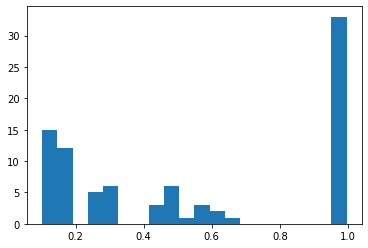

```python
import matplotlib.pyplot as plt
plt.hist(train_marginals, bins=20)
plt.show()
```

The distribution seems good, given that most classifiers are very close to either 0 or 1, as while it was initially very bad, but as I kept adding more labeling functions based on the FPs and FNs the distribution began to improve. The current distribution differentiates well between the classes, although its clear from the plot that defining what is a match is much easier than defining what is NOT a match.

```python
SentenceNgramViewer(fn, session)
```

## 3. Adding Distant Supervision Labeling Function

Distant supervision generates training data automatically using an external, imperfectly aligned training resource, such as a Knowledge Base.

Defining an additional distant-supervision-based labeling function which DBpedia.

```python
from SPARQLWrapper import SPARQLWrapper, JSON

titlecase_regex = re.compile('[A-Z][a-z][a-z]+')
def LF_distant_supervision(c):

    performance_title = c.performance.get_span()
    performance_strings = ' '.join(titlecase_regex.findall(performance_title))
    director_name = c.director.get_span()
    director_strings = ' '.join(titlecase_regex.findall(director_name))

    sparql = SPARQLWrapper("http://dbpedia.org/sparql")
    sparql.setQuery(f'''
        PREFIX dcterms: <http://purl.org/dc/terms/>
        PREFIX foaf: <http://xmlns.com/foaf/0.1/>
        PREFIX owl: <http://www.w3.org/2002/07/owl#>
        PREFIX rdfs: <http://www.w3.org/2000/01/rdf-schema#>
        PREFIX rdf: <http://www.w3.org/1999/02/22-rdf-syntax-ns#>
        PREFIX xml: <http://www.w3.org/XML/1998/namespace/>
        PREFIX xsd: <http://www.w3.org/2001/XMLSchema#>
        PREFIX dbo: <http://dbpedia.org/ontology/>
        prefix dbp: <http://dbpedia.org/property/>

        SELECT ?movie ?movieTitle ?directorName
        WHERE {{
        ?movie a dbo:Film .
        ?movie foaf:name ?movieTitle .
        ?movie dbp:director ?director .
        ?director foaf:name ?directorName .

        FILTER(CONTAINS(?movieTitle, "{performance_strings}"))
        FILTER(CONTAINS(?directorName , "{director_strings}"))
    }}
        ''')
    sparql.setReturnFormat(JSON)
    try:
        results = sparql.query().convert()
        binding = results['results']['bindings']
        movieTitle = binding[0]['movieTitle']['value']
        directorName = binding[0]['directorName']['value']
        match = True
    except:
        match = False
    if match:
        return TRUE
    else:
        return ABSTAIN
```

```python
performance_with_director_lfs = [
    LF_upper_lower_upper_P,
    LF_year_P,  LF_single_quotes_P, LF_single_quotes_D,
    LF_1_titlecase_apostrophe_D, LF_1_titlecase_apostrophe_P, LF_digit_P,
    LF_directed_by, LF_parenthesis_right, LF_year_between,
    LF_star, LF_act, LF_with, LF_commas_between,
    LF_feat, LF_featuring, LF_opposite,
    LF_titlecase_P, LF_titlecase_D,
    LF_which, LF_film, LF_work, LF_based, LF_quote_or_year,
    LF_movie_direct_P, LF_genre_D, LF_genre_P,
    LF_drama, LF_nominat, LF_final, LF_reunit, LF_document,
    LF_first_capitalized_D, LF_first_capitalized_P, LF_names_between,
    LF_partners, LF_movie_between,
    LF_actors_P, LF_relations,
    LF_distant_supervision
]
```

#### Check LFs Performance Before Generative Model Training

```python
# Pre-Train
np.random.seed(1701)
labeler = LabelAnnotator(lfs=performance_with_director_lfs)
L_train = labeler.apply(split=0)
L_train.lf_stats(session)
```

```
Clearing existing...
Running UDF...
[========================================] 100%
```

|  | j | Coverage | Overlaps | Conflicts |
| --- | --- | --- | --- | --- |
| LF_upper_lower_upper_P | 0 | 0.103448 | 0.103448 | 0.103448 |
| LF_year_P | 1 | 0.379310 | 0.379310 | 0.367816 |
| LF_single_quotes_P | 2 | 0.000000 | 0.000000 | 0.000000 |
| LF_single_quotes_D | 3 | 0.000000 | 0.000000 | 0.000000 |
| LF_1_titlecase_apostrophe_D | 4 | 0.000000 | 0.000000 | 0.000000 |
| LF_1_titlecase_apostrophe_P | 5 | 0.000000 | 0.000000 | 0.000000 |
| LF_digit_P | 6 | 0.390805 | 0.390805 | 0.379310 |
| LF_directed_by | 7 | 0.011494 | 0.011494 | 0.011494 |
| LF_parenthesis_right | 8 | 0.425287 | 0.425287 | 0.413793 |
| LF_year_between | 9 | 0.287356 | 0.287356 | 0.287356 |
| LF_star | 10 | 0.000000 | 0.000000 | 0.000000 |
| LF_act | 11 | 0.000000 | 0.000000 | 0.000000 |
| LF_with | 12 | 0.011494 | 0.011494 | 0.011494 |
| LF_commas_between | 13 | 0.344828 | 0.344828 | 0.103448 |
| LF_feat | 14 | 0.011494 | 0.011494 | 0.011494 |
| LF_featuring | 15 | 0.000000 | 0.000000 | 0.000000 |
| LF_opposite | 16 | 0.000000 | 0.000000 | 0.000000 |
| LF_titlecase_P | 17 | 0.000000 | 0.000000 | 0.000000 |
| LF_titlecase_D | 18 | 0.597701 | 0.574713 | 0.459770 |
| LF_which | 19 | 0.000000 | 0.000000 | 0.000000 |
| LF_film | 20 | 0.149425 | 0.149425 | 0.080460 |
| LF_work | 21 | 0.011494 | 0.011494 | 0.011494 |
| LF_based | 22 | 0.000000 | 0.000000 | 0.000000 |
| LF_quote_or_year | 23 | 0.379310 | 0.379310 | 0.367816 |
| LF_movie_direct_P | 24 | 0.000000 | 0.000000 | 0.000000 |
| LF_genre_D | 25 | 0.000000 | 0.000000 | 0.000000 |
| LF_genre_P | 26 | 0.068966 | 0.068966 | 0.034483 |
| LF_drama | 27 | 0.000000 | 0.000000 | 0.000000 |
| LF_nominat | 28 | 0.011494 | 0.011494 | 0.011494 |
| LF_final | 29 | 0.000000 | 0.000000 | 0.000000 |
| LF_reunit | 30 | 0.000000 | 0.000000 | 0.000000 |
| LF_document | 31 | 0.149425 | 0.149425 | 0.080460 |
| LF_first_capitalized_D | 32 | 0.000000 | 0.000000 | 0.000000 |
| LF_first_capitalized_P | 33 | 0.310345 | 0.298851 | 0.183908 |
| LF_names_between | 34 | 0.367816 | 0.344828 | 0.103448 |
| LF_partners | 35 | 0.000000 | 0.000000 | 0.000000 |
| LF_movie_between | 36 | 0.045977 | 0.045977 | 0.045977 |
| LF_actors_P | 37 | 0.022989 | 0.022989 | 0.022989 |
| LF_relations | 38 | 0.000000 | 0.000000 | 0.000000 |
| LF_distant_supervision | 39 | 0.000000 | 0.000000 | 0.000000 |

```python
# Post-Train
gen_model = GenerativeModel()
gen_model.train(L_train, epochs=100, decay=0.95, step_size=0.1 / L_train.shape[0], reg_param=1e-6)
print("LF weights:", gen_model.weights.lf_accuracy)
L_gold_dev = load_gold_labels(session, annotator_name='gold', split=1)
L_dev = labeler.apply_existing(split=1)
tp, fp, tn, fn = gen_model.error_analysis(session, L_dev, L_gold_dev)
L_dev.lf_stats(session, L_gold_dev, gen_model.learned_lf_stats()['Accuracy'])
```

```
Inferred cardinality: 2
LF weights: [ 0.19934435  0.61384383  0.06455938  0.04292462  0.08248233  0.08152397
  0.58449047  0.0616631   0.42670369 -0.0365053   0.06014309  0.09214489
  0.09174504  0.51274644  0.07547928  0.05926433  0.07285599  0.07276436
 -0.16940715  0.05422622  0.24344786  0.06373718  0.07257566  0.63409584
  0.08521251  0.07471332  0.11782195  0.0683143   0.08196633  0.05047449
  0.0815411   0.23043219  0.07798068  0.00841972  0.5565986   0.08851671
  0.03295081  0.04766071  0.06534586  0.05237717]
Clearing existing...
Running UDF...
[========================================] 100%

========================================
Scores (Un-adjusted)
========================================
Pos. class accuracy: 0.565
Neg. class accuracy: 0.677
Precision            0.798
Recall               0.565
F1                   0.661
----------------------------------------
TP: 83 | FP: 21 | TN: 44 | FN: 64
========================================
```

|  | j | Coverage | Overlaps | Conflicts | TP | FP | FN | TN | Empirical Acc. | Learned Acc. |
| --- | --- | --- | --- | --- | --- | --- | --- | --- | --- | --- |
| LF_upper_lower_upper_P | 0 | 0.047170 | 0.023585 | 0.023585 | 10 | 0 | 0 | 0 | 1.000000 | 0.590970 |
| LF_year_P | 1 | 0.216981 | 0.216981 | 0.174528 | 30 | 16 | 0 | 0 | 0.652174 | 0.772611 |
| LF_single_quotes_P | 2 | 0.084906 | 0.084906 | 0.066038 | 15 | 3 | 0 | 0 | 0.833333 | 0.541915 |
| LF_single_quotes_D | 3 | 0.000000 | 0.000000 | 0.000000 | 0 | 0 | 0 | 0 | NaN | 0.526420 |
| LF_1_titlecase_apostrophe_D | 4 | 0.099057 | 0.094340 | 0.089623 | 17 | 4 | 0 | 0 | 0.809524 | 0.537210 |
| LF_1_titlecase_apostrophe_P | 5 | 0.000000 | 0.000000 | 0.000000 | 0 | 0 | 0 | 0 | NaN | 0.546671 |
| LF_digit_P | 6 | 0.297170 | 0.297170 | 0.245283 | 47 | 16 | 0 | 0 | 0.746032 | 0.764621 |
| LF_directed_by | 7 | 0.325472 | 0.311321 | 0.297170 | 55 | 14 | 0 | 0 | 0.797101 | 0.538139 |
| LF_parenthesis_right | 8 | 0.136792 | 0.117925 | 0.108491 | 24 | 5 | 0 | 0 | 0.827586 | 0.702266 |
| LF_year_between | 9 | 0.193396 | 0.193396 | 0.174528 | 0 | 0 | 30 | 11 | 0.268293 | 0.481129 |
| LF_star | 10 | 0.009434 | 0.009434 | 0.009434 | 0 | 0 | 2 | 0 | 0.000000 | 0.522619 |
| LF_act | 11 | 0.047170 | 0.037736 | 0.014151 | 0 | 0 | 1 | 9 | 0.900000 | 0.553109 |
| LF_with | 12 | 0.056604 | 0.056604 | 0.028302 | 0 | 0 | 3 | 9 | 0.750000 | 0.551020 |
| LF_commas_between | 13 | 0.207547 | 0.207547 | 0.202830 | 0 | 0 | 29 | 15 | 0.340909 | 0.743442 |
| LF_feat | 14 | 0.056604 | 0.056604 | 0.037736 | 0 | 0 | 1 | 11 | 0.916667 | 0.533938 |
| LF_featuring | 15 | 0.047170 | 0.047170 | 0.028302 | 0 | 0 | 0 | 10 | 1.000000 | 0.533858 |
| LF_opposite | 16 | 0.037736 | 0.037736 | 0.028302 | 0 | 0 | 0 | 8 | 1.000000 | 0.526697 |
| LF_titlecase_P | 17 | 0.146226 | 0.146226 | 0.080189 | 0 | 0 | 21 | 10 | 0.322581 | 0.535167 |
| LF_titlecase_D | 18 | 0.212264 | 0.212264 | 0.169811 | 0 | 0 | 32 | 13 | 0.288889 | 0.412569 |
| LF_which | 19 | 0.014151 | 0.014151 | 0.009434 | 0 | 0 | 0 | 3 | 1.000000 | 0.524031 |
| LF_film | 20 | 0.009434 | 0.009434 | 0.000000 | 0 | 0 | 0 | 2 | 1.000000 | 0.622605 |
| LF_work | 21 | 0.018868 | 0.018868 | 0.000000 | 0 | 0 | 0 | 4 | 1.000000 | 0.533173 |
| LF_based | 22 | 0.023585 | 0.023585 | 0.023585 | 0 | 0 | 3 | 2 | 0.400000 | 0.525683 |
| LF_quote_or_year | 23 | 0.301887 | 0.301887 | 0.240566 | 45 | 19 | 0 | 0 | 0.703125 | 0.782424 |
| LF_movie_direct_P | 24 | 0.099057 | 0.099057 | 0.042453 | 0 | 0 | 11 | 10 | 0.476190 | 0.555423 |
| LF_genre_D | 25 | 0.000000 | 0.000000 | 0.000000 | 0 | 0 | 0 | 0 | NaN | 0.535235 |
| LF_genre_P | 26 | 0.221698 | 0.221698 | 0.146226 | 0 | 0 | 17 | 30 | 0.638298 | 0.560012 |
| LF_drama | 27 | 0.028302 | 0.028302 | 0.028302 | 0 | 0 | 2 | 4 | 0.666667 | 0.533452 |
| LF_nominat | 28 | 0.056604 | 0.056604 | 0.037736 | 0 | 0 | 1 | 11 | 0.916667 | 0.536760 |
| LF_final | 29 | 0.014151 | 0.014151 | 0.014151 | 0 | 0 | 0 | 3 | 1.000000 | 0.522338 |
| LF_reunit | 30 | 0.018868 | 0.018868 | 0.018868 | 0 | 0 | 2 | 2 | 0.500000 | 0.537835 |
| LF_document | 31 | 0.018868 | 0.018868 | 0.009434 | 0 | 0 | 1 | 3 | 0.750000 | 0.617223 |
| LF_first_capitalized_D | 32 | 0.009434 | 0.009434 | 0.000000 | 0 | 0 | 2 | 0 | 0.000000 | 0.529287 |
| LF_first_capitalized_P | 33 | 0.466981 | 0.452830 | 0.367925 | 0 | 0 | 65 | 34 | 0.343434 | 0.500893 |
| LF_names_between | 34 | 0.367925 | 0.363208 | 0.330189 | 0 | 0 | 52 | 26 | 0.333333 | 0.755467 |
| LF_partners | 35 | 0.037736 | 0.037736 | 0.028302 | 0 | 0 | 0 | 8 | 1.000000 | 0.556621 |
| LF_movie_between | 36 | 0.047170 | 0.047170 | 0.047170 | 0 | 0 | 4 | 6 | 0.600000 | 0.517085 |
| LF_actors_P | 37 | 0.014151 | 0.014151 | 0.004717 | 0 | 0 | 1 | 2 | 0.666667 | 0.525041 |
| LF_relations | 38 | 0.070755 | 0.070755 | 0.070755 | 0 | 0 | 2 | 13 | 0.866667 | 0.539685 |
| LF_distant_supervision | 39 | 0.051887 | 0.047170 | 0.042453 | 11 | 0 | 0 | 0 | 1.000000 | 0.525226 |

#### Check distribution of the training marginals

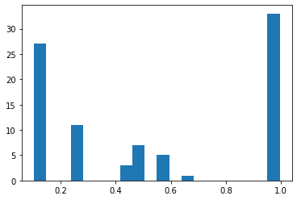

```python
train_marginals = gen_model.marginals(L_train)
plt.hist(train_marginals, bins=20)
plt.show()
```

The distribution seems good, given that most classifiers are very close to either 0 or 1, as while it was initially very bad, but as I kept adding more labeling functions based on the FPs and FNs the distribution began to improve. The current distribution differentiates well between the classes, although its clear from the plot that defining what is a match is much easier than defining what is NOT a match.

## 4. Training an Discriminative Model

Using the noisy training labels we generated to train our end extraction model. In particular, we will be training a Bi-LSTM.

```python
train_cands = session.query(performance_with_director).filter(performance_with_director.split == 0).order_by(performance_with_director.id).all()
dev_cands   = session.query(performance_with_director).filter(performance_with_director.split == 1).order_by(performance_with_director.id).all()
```

```python
from snorkel.annotations import load_gold_labels

L_gold_dev  = load_gold_labels(session, annotator_name='gold', split=1)
```

Try tuning the hyper-parameters below to get your best F1 score

```python
from snorkel.learning.pytorch import LSTM

train_kwargs = {
    'lr':            0.01, # learning rate of the model
    'embedding_dim': 50,   # size of the feature vector
    'hidden_dim':    20,   # number of nodes in each layer in the model
    'n_epochs':      10,   # number of training epochs
    'dropout':       0.5,  # dropout rate (during learning)
    'batch_size':    32,   # training batch size
    'seed':          1701
}

lstm = LSTM(n_threads=-1)
lstm.train(train_cands, train_marginals, X_dev=dev_cands, Y_dev=L_gold_dev, **train_kwargs)
```

[output not shown]

#### Hyper-Parameter Tuning

Surprisingly, I found that 50 neurons in the hidden layer were actually too much for this ultra-small (82 samples) dataset, and when I cut the neurons to 20 I saw a good increase in F1 score (mostly because with more neurons recall starts to worsen).

I reduced the learning rate by an order of magnitudef which improved performance too. Presumably because given such a small, overfit-prone dataset, we really have to go slow then training.

Given the small train dataset size, one of the most significative changes I made was reducing the batch sizea from 64 to 32, which seems to have made overfitting slightly less of an issue.

## Report Performance of the Final Extractor

```python
p, r, f1 = lstm.score(dev_cands, L_gold_dev)
print("Prec: {0:.3f}, Recall: {1:.3f}, F1 Score: {2:.3f}".format(p, r, f1))
```

```
Prec: 0.716, Recall: 0.959, F1 Score: 0.820
```

It took a lot of tweaking, but in the end I managed to convert the good distribution of marginals into good F1 Scores with the trained model. This was mostly a results of tuning hyperparameters with the small dataset in mind.

```python
tp, fp, tn, fn = lstm.error_analysis(session, dev_cands, L_gold_dev)
```

```
========================================
Scores (Un-adjusted)
========================================
Pos. class accuracy: 0.959
Neg. class accuracy: 0.138
Precision            0.716
Recall               0.959
F1                   0.82
----------------------------------------
TP: 141 | FP: 56 | TN: 9 | FN: 6
========================================
```

Generally speaking my model's weak point is in accurately predicting non-matches, as defining what is *NOT* a match in a string proved to be the hardest aspect of developing the labeling functions, as can be seen by the difficulty of getting a bar stacked at 0 on the marginals.

```python
# Export the DEV set prediction to a CSV file

list_performances = []
list_directors = []
list_ids = []
for i in range(len(dev_cands)):
    list_ids.append(dev_cands[i][0].get_stable_id().split('::')[0])
    list_performances.append(dev_cands[i][0].get_attrib_span('words'))
    list_directors.append(dev_cands[i][1].get_attrib_span('words'))


dev_preds = lstm.predictions(dev_cands)

predictions_df = pd.DataFrame(data = {'id': list_ids,
                                      'performance': list_performances,
                                      'director': list_directors,
                                      'prediction': dev_preds})
print(f'predictions_df.shape: {predictions_df.shape}')
predictions_df.to_csv(HW_DIR / "Matheus_Schmitz_hw05_pred.dev.csv", index=False, header=False)
```

```
predictions_df.shape: (212, 4)
```

# End

Matheus Schmitz  
[LinkedIn](https://www.linkedin.com/in/matheusschmitz/)  
[Github Portfolio](https://matheus-schmitz.github.io/)